# AI5-P1

## This is project No.5 and the aim of this project is to implement Forward Feed neural networks to classify images.

### Introduction

In Forward Feed neural networks, each image is first flattened and given as a vector as network input. Each element of this vector (equivalent to one pixel of the image) is a property for it. Predict the corresponding input image class correctly.

# Phase One: Data review and pre-processing

```python
import pickle
import numpy as np
import pandas as pd
import matplotlib.pyplot as plt
from sklearn.model_selection import train_test_split
from random import randint
import cv2
from sklearn.utils import shuffle
np.warnings.filterwarnings('ignore', category=np.VisibleDeprecationWarning)

FIXED_SIZE = 25
UNIQUE_VALUES = 10
```

```python
pkl_file = open('dataset/data.pkl', 'rb')
data_set = pickle.load(pkl_file)
pkl_file = open('dataset/labels.pkl', 'rb')
labels = pickle.load(pkl_file)
```

### Reasonably, use the photos to train and test your model. In what range are the values of each pixel?

Each pixel is in range between 0 to 255.

```python
X_train, X_test, y_train, y_test = train_test_split(data_set, labels, test_size=0.33, random_state=1, stratify=labels)
len(X_train), len(y_train), len(X_test), len(y_test)
```

```
(68575, 68575, 33777, 33777)
```

### Check and display an image in the train dataset randomly.

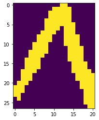

```python
plt.imshow(X_train[randint(0, len(X_train))])
plt.show()
```

### Since the size of the images is different, change the size of the images to 25 by 25.

```python
np.shape(X_train)
```

```
(68575,)
```

```python
curr_X = []
for index, item in enumerate(X_train):
    curr_X.append(cv2.resize(item, (FIXED_SIZE, FIXED_SIZE)))
X_train = curr_X

curr_X = []
for index, item in enumerate(X_test):
    curr_X.append(cv2.resize(item, (FIXED_SIZE, FIXED_SIZE)))
X_test = curr_X
```

```python
np.shape(X_train)
```

```
(68575, 25, 25)
```

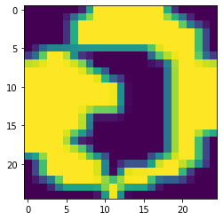

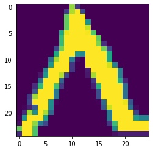

```python
plt.imshow(X_train[randint(0, len(X_train))])
plt.show()

plt.imshow(X_test[randint(0, len(X_test))])
plt.show()
```

### In the train data set, select and display an image from each class. For each image, display its type with the image.

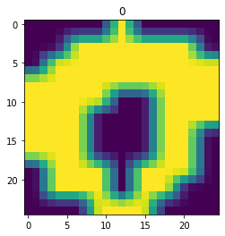

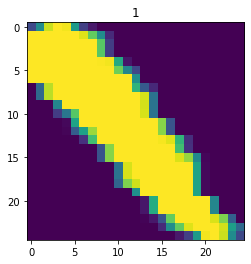

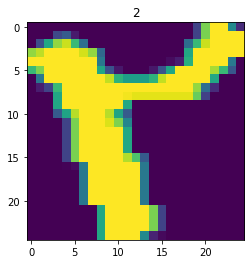

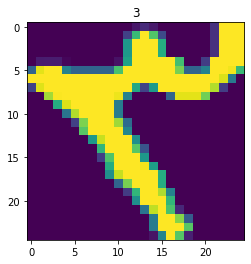

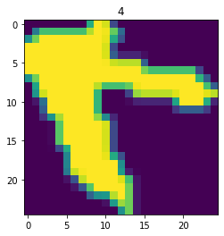

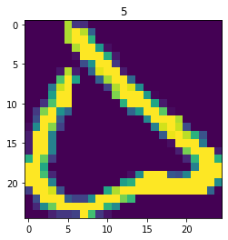

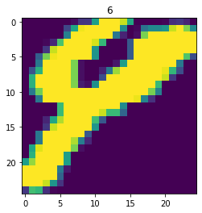

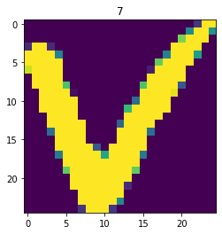

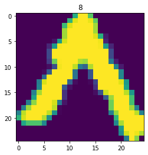

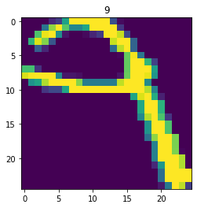

```python
unique_array, unique_index = np.unique(y_train, return_index=True)
for number, index in enumerate(unique_index):
    plt.imshow(X_train[index])
    plt.title(number)
    plt.show()
```

### Calculate the number of images in each category for the train and test datasets and plot bar graphs for them.

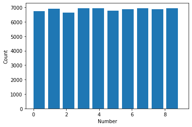

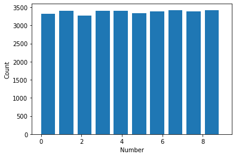

```python
for curr_data_set in [y_train, y_test]:
    plt.hist(curr_data_set, width = 0.7);
    plt.xlabel("Number")
    plt.ylabel("Count")
    plt.show()
```

### Scale the amount of data so that the value of each pixel is between 0 and 1 before giving information to the neural network. What can happen if you do not do this?

Among the best practices for training a Neural Network is to normalize your data to obtain a mean close to 0. Normalizing the data generally speeds up learning and leads to faster convergence.  
When you input unnormalized inputs to activation functions, you can get stuck in a very flat region in the domain and may not learn at all. Or worse, you can end up with numerical issues.

```python
for index in range(len(X_train)):
    X_train[index] = np.true_divide(X_train[index], 255)
for index in range(len(X_test)):
    X_test[index] = np.true_divide(X_test[index], 255)
```

```python
X_test = np.array(X_test)
X_train = np.array(X_train)
y_test = np.array(y_test)
y_train = np.array(y_train)
```

# Phase Two: Completion of incomplete parts of the neural network

# Dataloader

```python
class Dataloader:
    '''
    This class prepares the dataset for the neural network.
    '''

    def __init__(self, data, labels, n_classes, batch_size=None, shuffle=False):
        '''
        This is the constructor. It gets dataset information and initializes the
        Dataloader class fields.
            Parameters:
                data: features your dataset in pandas.Dataframe format.
                labels: labels of your dataset in pandas.Dataframe format.
                n_classes: number of classes you have in your dataset.
                batch_size: the number of samples that will be propagated through the network.
                shuffle: boolean value indicating whether or not the dataset should be shuffled
        '''

        assert len(data)==len(labels)
        self.__n_classes = n_classes
        self.__batch_size = batch_size
        self.__shuffle = shuffle
        self.__data = data
        self.__onehot_labels = self.__onehot(labels, self.__n_classes)

    def __onehot(self, labels, n_classes):
        '''
        This private method gets labels and provides one_hot vectors of labels.
        For categorical variables where no such ordinal relationship exists,
        the integer encoding is not enough.
        In this case, a one-hot encoding can be applied to the integer representation.
        This is where the integer encoded variable is removed, and a new binary variable is
        added for each unique integer value.
        example:
            red,    green,    blue
            1,      0,        0
            0,      1,        0
            0,      0,        1
                Parameters:
                        label: lables of your dataset in pandas.Dataframe format.
                        n_classes: number of classes you have in your dataset.

                Returns:
                    onehot_vectors: onehot vectors of the labels
        '''
        # TODO: Implement
        onehot_vectors = np.zeros((len(labels), n_classes))
        # print(labels[:5])
        for index in range(len(labels)):
            onehot_vectors[index, labels[index]] = 1.0
        # print(onehot_vectors[:5])
        return onehot_vectors

    def __shuffle_dataset(self):
        '''
        This private method shuffles your dataset.
        It uses data and onehot_labels to shuffle them
        symmetrical.
        '''
        # TODO: Implement
        self.__data, self.__onehot_labels = shuffle(self.__data, self.__onehot_labels)

    def __iter__(self):
        '''
        The __iter__() function returns an iterator for the
        given object (array, set, tuple, etc., or custom objects).
        This will return your dataset in the batch_size given. This should
        be used to provide data for the neural network.
        '''

        if self.__shuffle:
            self.__shuffle_dataset()

        if self.__batch_size==None:
            yield (np.matrix(self.__data), np.matrix(self.__onehot_labels))
            return

        for idx in range(0, len(self.__data), self.__batch_size):
            yield (np.matrix(self.__data[idx:idx+self.__batch_size]),
                   np.matrix(self.__onehot_labels[idx:idx+self.__batch_size]))
```

```python
train_loader = Dataloader(X_train, y_train, UNIQUE_VALUES, batch_size=32)
```

# Activation Functions

```python
class Identical:
    '''
    This is the Identical activation function. This activation function just
    return the value it gets.
    '''

    def __init__(self):
        '''
        This is the constructor. It does not have any fields
        as a result, there is no need to do anything in the constructor.
        '''
        pass

    def __val(self, matrix):
        '''
        This private method gets a matrix and uses the activity function on that.
        As this is an identical activity function, it just
        returns np.matrix of the input.

            Parameters:
                matrix: np.matrix of values
            Returns:
                identical_value: np.matrix of input with float datatypes
        '''
        identical_value = np.matrix(matrix, dtype=float)
        return identical_value

    def derivative(self, matrix):
        '''
        This method returns the derivation of the input.
        As the derivation of x is one, this method returns
        a matrix of one with the shape of the input matrix.

            Parameters:
                matrix: np.matrix of values
            Returns:
                identical_derivative: np.matrix of ones with matrix shape
        '''
        temp = np.matrix(matrix, dtype=float)
        identical_derivative = np.matrix(np.full(np.shape(temp), 1.))
        return identical_derivative

    def __call__(self, matrix):
        '''
        __call__ is a special function in Python that, when implemented inside a class,
        gives its instances (objects) the ability to behave like a function.
        Here we return the _value method output.

            Parameters:
                matrix: np.matrix of values
            Returns:
                __val(matrix): __val return value for the input matrix
        '''
        return self.__val(matrix)
```

```python
test_matrix = np.matrix([[1,-2], [-3,4], [5, 6], [-7, -8]])
identical = Identical()
print(test_matrix)
print()
print(identical(test_matrix))
print()
print(identical.derivative(test_matrix))
```

```
[[ 1 -2]
 [-3  4]
 [ 5  6]
 [-7 -8]]

[[ 1. -2.]
 [-3.  4.]
 [ 5.  6.]
 [-7. -8.]]

[[1. 1.]
 [1. 1.]
 [1. 1.]
 [1. 1.]]
```

```python
class Relu:
    '''
    This is the Relu activation function.
    The rectified linear activation function or ReLU for short
    is a piecewise linear function that will output the input directly
    if it is positive, otherwise, it will output zero.
    '''

    def __init__(self):
        '''
        This is the constructor. It does not have any fields
        as a result, there is no need to do anything in the constructor.
        '''
        pass

    def __val(self, matrix):
        '''
        This private method gets a matrix and uses the activity function on that.
        It will set 0 in the matrix if the value is less than 0 else, it returns the value itself.

            Parameters:
                matrix: np.matrix of values
            Returns:
                relu_value: np.matrix of relu activation function result
        '''
        # TODO: Implement
        relu_value = np.matrix(matrix, dtype=float)
        relu_value = np.maximum(0, relu_value)
        return relu_value

    def derivative(self, matrix):
        '''
        Returns the derivation value of relu function on input matrix.

            Parameters:
                matrix: np.matrix of values
            Returns:
                relu_derivative: np.matrix of relu activation function derivation result
        '''
        # TODO: Implement
        relu_derivative = np.matrix(matrix, dtype=float)
        relu_derivative[relu_derivative <= 0] = 0.0
        relu_derivative[relu_derivative > 0] = 1.0
        return relu_derivative

    def __call__(self, matrix):
        '''
        __call__ is a special function in Python that, when implemented inside a class,
        gives its instances (objects) the ability to behave like a function.
        Here we return the _relu method output.

            Parameters:
                matrix: np.matrix of values
            Returns:
                __relu(matrix): __relu return value for the input matrix
        '''
        return self.__val(matrix)
```

```python
test_matrix = np.matrix([[1,-2], [-3,4], [5, 6], [-7, -8]])
relu = Relu()
print(test_matrix)
print()
print(relu(test_matrix))
print()
print(relu.derivative(test_matrix))
```

```
[[ 1 -2]
 [-3  4]
 [ 5  6]
 [-7 -8]]

[[1. 0.]
 [0. 4.]
 [5. 6.]
 [0. 0.]]

[[1. 0.]
 [0. 1.]
 [1. 1.]
 [0. 0.]]
```

```python
class LeakyRelu:
    '''
    This is the Leaky Relu activation function.
    Leaky Rectified Linear Unit, or Leaky ReLU,
    is a type of activation function based on a ReLU,
    but it has a small slope for negative values instead
    of a flat slope.
    '''

    def __init__(self, negative_slope=0.01):
        '''
        This is the constructor.
        It sets negative_slope field.
            Parameters:
                negative_slope: slope for negative input values
        '''
        self.negative_slope = negative_slope

    def __val(self, matrix):
        '''
        This private method gets a matrix and uses the activity function on that.
        It will set negative_slope*value in the matrix if the value is less than 0, else it
        returns the value itself.

            Parameters:
                matrix: np.matrix of values
            Returns:
                relu_value: np.matrix of relu activation function result
        '''
        # TODO: Implement
        leacky_relu_value = np.matrix(matrix, dtype=float)
        leacky_relu_value = np.maximum(self.negative_slope*leacky_relu_value, leacky_relu_value)
        return leacky_relu_value

    def derivative(self, matrix):
        '''
        Returns the derivation value of leaky relu function on input matrix.

            Parameters:
                matrix: np.matrix of values
            Returns:
                leacky_relu_derivative: np.matrix of leaky relu activation function derivation result
        '''
        # TODO: Implement
        leacky_relu_derivative = np.matrix(matrix, dtype=float)
        leacky_relu_derivative[leacky_relu_derivative > 0] = 1.0
        leacky_relu_derivative[leacky_relu_derivative <= 0] = self.negative_slope
        return leacky_relu_derivative

    def __call__(self, matrix):
        '''
        __call__ is a special function in Python that, when implemented inside a class,
        gives its instances (objects) the ability to behave like a function.
        Here we return the _val method output.

            Parameters:
                matrix: np.matrix of values
            Returns:
                __val(matrix): __val return value for the input matrix
        '''
        return self.__val(matrix)
```

```python
test_matrix = np.matrix([[1,-2], [-3,4], [5, 6], [-7, -8]])
leakyRelu = LeakyRelu()
print(test_matrix)
print()
print(leakyRelu(test_matrix))
print()
print(leakyRelu.derivative(test_matrix))
```

```
[[ 1 -2]
 [-3  4]
 [ 5  6]
 [-7 -8]]

[[ 1.   -0.02]
 [-0.03  4.  ]
 [ 5.    6.  ]
 [-0.07 -0.08]]

[[1.   0.01]
 [0.01 1.  ]
 [1.   1.  ]
 [0.01 0.01]]
```

```python
class Sigmoid:
    '''
    A sigmoid function is a mathematical function having a
    characteristic "S"-shaped curve or sigmoid curve.
    It return S(x)=1/(1+e^-x)
    '''

    def __init__(self): pass

    def __val(self, matrix):
        '''
        Returns 1/(1+e^-x) of values

            Parameters:
                matrix: np.matrix of values
            Returns:
                sigmoid_value: np.matrix of relu activation function result
        '''
        # TODO: Implement
        sigmoid_value = np.matrix(matrix, dtype=float)
        sigmoid_value = 1/(1 + np.exp(-sigmoid_value))
        return sigmoid_value

    def derivative(self, matrix):
        '''
        Returns the derivation value of sigmoid function on input matrix.

            Parameters:
                matrix: np.matrix of values
            Returns:
                sigmoid_derivative: np.matrix of sigmoid activation function derivation result
        '''
        # TODO: Implement
        sigmoid_derivative = np.matrix(matrix, dtype=float)
        sigmoid_derivative = np.divide(np.exp(-sigmoid_derivative), np.power(1 + np.exp(-sigmoid_derivative), 2))
        return sigmoid_derivative

    def __call__(self, matrix):
        '''
        __call__ is a special function in Python that, when implemented inside a class,
        gives its instances (objects) the ability to behave like a function.
        Here we return the _val method output.

            Parameters:
                matrix: np.matrix of values
            Returns:
                __val(matrix): __val return value for the input matrix
        '''
        return self.__val(matrix)
```

```python
test_matrix = np.matrix([[1,-2], [-3,4], [5, 6], [-7, -8]])
sigmoid = Sigmoid()
print(test_matrix)
print()
print(sigmoid(test_matrix))
print()
print(sigmoid.derivative(test_matrix))
```

```
[[ 1 -2]
 [-3  4]
 [ 5  6]
 [-7 -8]]

[[7.31058579e-01 1.19202922e-01]
 [4.74258732e-02 9.82013790e-01]
 [9.93307149e-01 9.97527377e-01]
 [9.11051194e-04 3.35350130e-04]]

[[0.19661193 0.10499359]
 [0.04517666 0.01766271]
 [0.00664806 0.00246651]
 [0.00091022 0.00033524]]
```

```python
class Softmax:
    '''
    The softmax function, also known as softargmax  or normalized
    exponential function is a generalization of the logistic
    function to multiple dimensions. It is used in multinomial logistic
    regression and is often used as the last activation function of a neural
    network to normalize the output of a network to a probability distribution
    over predicted output classes, based on Luce's choice axiom.
    Softmax return (e^x_i / (Σe^x_j for j = 1, ..., J))
    '''

    def __init__(self):
        '''
        This is the constructor. It does not have any fields
        as a result, there is no need to do anything in the constructor.
        '''
        pass

    def __val(self, matrix):
        '''
        This private method gets a matrix and uses the softmax on that.
        Softmax return (e^x_i / (Σe^x_j for j = 1, ..., J))

            Parameters:
                matrix: np.matrix of values
            Returns:
                relu_value: np.matrix of relu activation function result
        '''
        # TODO: Implement
        temp = np.matrix(matrix, dtype=float)
        softmax_value = np.exp(temp - np.max(temp))
        softmax_value /= softmax_value.sum(axis=1)
        return softmax_value

    def __call__(self, matrix):
        '''
        __call__ is a special function in Python that, when implemented inside a class,
        gives its instances (objects) the ability to behave like a function.
        Here we return the _val method output.

            Parameters:
                matrix: np.matrix of values
            Returns:
                __val(matrix): __val return value for the input matrix
        '''
        return self.__val(matrix)
```

```python
test_matrix = np.matrix([[1,-2], [-3,4], [5, 6], [-7, -8]])
softmax = Softmax()
print(test_matrix)
print()
print(softmax(test_matrix))
```

```
[[ 1 -2]
 [-3  4]
 [ 5  6]
 [-7 -8]]

[[9.52574127e-01 4.74258732e-02]
 [9.11051194e-04 9.99088949e-01]
 [2.68941421e-01 7.31058579e-01]
 [7.31058579e-01 2.68941421e-01]]
```

```python
class Tanh:

    def __init__(self):
        '''
        This is the constructor. It does not have any fields
        as a result, there is no need to do anything in the constructor.
        '''
        pass

    def __val(self, matrix):
        '''
        This private method gets a matrix and uses the activity function on that.
        It performs Tanh on the values.

            Parameters:
                matrix: np.matrix of values
            Returns:
                tanh_value: np.matrix of Tanh activation function result
        '''
        # TODO: Implement
        tanh_value = np.matrix(matrix, dtype=float)
        tanh_value = np.tanh(tanh_value)
        return tanh_value

    def derivative(self, matrix):
        '''
        Returns the derivation value of Tanh function on input matrix.

            Parameters:
                matrix: np.matrix of values
            Returns:
                sigmoid_derivative: np.matrix of Tanh activation function derivation result
        '''
        # TODO: Implement
        tanh_derivative = np.matrix(matrix, dtype=float)
        tanh_derivative = np.power(np.divide(1, np.cosh(tanh_derivative)), 2)
        return tanh_derivative

    def __call__(self, matrix):
        '''
        __call__ is a special function in Python that, when implemented inside a class,
        gives its instances (objects) the ability to behave like a function.
        Here we return the _val method output.

            Parameters:
                matrix: np.matrix of values
            Returns:
                __val(matrix): __val return value for the input matrix
        '''
        return self.__val(matrix)
```

```python
test_matrix = np.matrix([[1,-2], [-3,4], [5, 6], [-7, -8]])
tanh = Tanh()
print(test_matrix)
print()
print(tanh(test_matrix))
print()
print(tanh.derivative(test_matrix))
```

```
[[ 1 -2]
 [-3  4]
 [ 5  6]
 [-7 -8]]

[[ 0.76159416 -0.96402758]
 [-0.99505475  0.9993293 ]
 [ 0.9999092   0.99998771]
 [-0.99999834 -0.99999977]]

[[4.19974342e-01 7.06508249e-02]
 [9.86603717e-03 1.34095068e-03]
 [1.81583231e-04 2.45765474e-05]
 [3.32610934e-06 4.50140598e-07]]
```


# Loss Function

```python
class CrossEntropy: #(with softmax)
    '''
    Cross-entropy is a measure of the difference between two probability
    distributions for a given random variable or set of events. You might
    recall that information quantifies the number of bits required to encode
    and transmit an event.
    The above image can help you.
    '''

    def __init__(self):
        '''
        This is the constructor. It does not have any fields
        as a result, there is no need to do anything in the constructor.
        '''
        pass

    def __val(self, true_val, expected_val):
        '''
        L(y^, y) = - Σ (y^(k)log (y^)^(k)) for k in K
        Parameters:
            true_val: calculated values (generated by neural network)
            expected_val: real values in dataset
        Returns:
            cross_entropy_value: cross entropy of inputs
        '''
        assert np.shape(true_val)==np.shape(expected_val)
        # TODO: Implement
        softmax = Softmax()
        cross_entropy_value = np.sum(-np.multiply(np.matrix(expected_val, dtype=float),  np.log(softmax(true_val))), axis=1)
        return cross_entropy_value

    def derivative(self, true_val, expected_val):
        '''
        Returns derivation of cross entropy.
            Parameters:
                true_val: calculated values (generated by neural network)
                expected_val: real values in dataset
            Returns:
                cross_entropy_derivative: cross entropy derivation of inputs
        '''
        assert np.shape(true_val)==np.shape(expected_val)
        # TODO: Implement
        softmax = Softmax()
        cross_entropy_derivative = softmax(true_val) - expected_val
        return cross_entropy_derivative

    def __call__(self, true_val, expected_val):
        '''
        __call__ is a special function in Python that, when implemented inside a class,
        gives its instances (objects) the ability to behave like a function.
        Here we return the _val method output.

            Parameters:
                true_val: calculated values (generated by neural network)
                expected_val: real values in dataset
            Returns:
                __val(matrix): __val return value for the input matrix
        '''
        return self.__val(true_val, expected_val)
```

# Layer

```python
class Layer:
    '''
    The layer class is used to define neural network layers.
    It stores all needed information for each layer, such as neurons count,
    weight matrix, bias, the output after applying the activation function, etc.
    '''

    DEFAULT_LOW, DEFAULT_HIGH, DEFAULT_MEAN, DEFAULT_VAR = 0, 0.05, 0., 1.

    def __init__(self, input_size, output_size, activation=Identical(), initial_weight='uniform',
                 **initializing_parameters):
        '''
        Parameters:
            input_size: the size of the input of this layer.
            output_size: the size of the output after this layer.
            activation: the activation function. It can be initialized to either of the previously defined activation classes.
                               default is an Identical activation function.
            initial_weight: either normal or uniform. It defines the method for weight initialization.
        '''

        assert type(initial_weight)==str, 'Undefined activation function!'

        self.__weight_initializer_dict = {'uniform':self.__uniform_weight, 'normal':self.__normal_weight}

        assert initial_weight in self.__weight_initializer_dict, 'Undefined weight initialization function!'


        self.__n_neurons = output_size
        weight_initializer = self.__weight_initializer_dict[initial_weight]
        self.__weight = weight_initializer(input_size, self.__n_neurons, **initializing_parameters)
        self.__bias = weight_initializer(1, self.__n_neurons, **initializing_parameters)
        self.__activation = activation

        self.__last_input = None
        self.__last_activation_input = None
        self.__last_activation_output = None
        self.__last_activation_derivative = None

    def forward(self, layer_input):
        '''
        It calculates the output of this layer for the layer_input argument.
        This method also stores __last_input, __last_activation_input, and __last_activation_derivative
        for future use in backpropagation.
        Parameters:
            layer_input: 2d np.matrix representing the input matrix of this layer.
        Returns:
            Final output of this layer after applying the activation function.
        '''
        assert np.ndim(layer_input)==2
        assert np.size(self.__weight,0) == np.size(layer_input,1)
        # TODO: Implement
        self.__last_input = layer_input
        self.__last_activation_input = np.add(np.dot(self.__last_input, self.__weight), self.__bias)
        self.__last_activation_output = self.__activation(self.__last_activation_input)
        self.__last_activation_derivative = self.__activation.derivative(self.__last_activation_output)
        return self.__last_activation_output

    def update_weights(self, backprop_tensor, lr):
        '''
        It updates Layer weights according to the backpropagation matrix and learning rate.
        This method updates bias values as well.
        Parameters:
            backprop_tensor: 2d np.matrix passed from the next layer containing gradient values.
            lr: learning rate
        Returns:
            backprop_tensor to be used by the previous layer.
        '''
        assert np.ndim(backprop_tensor)==2
        assert np.size(backprop_tensor,0) == np.size(self.__last_activation_derivative,0)
        assert np.size(backprop_tensor,1) == self.__n_neurons
        # TODO: Implement
        inputT = self.__last_input.transpose()
        dy = np.multiply(backprop_tensor, self.__last_activation_derivative)
        dw = np.matmul(inputT, dy)
        backprop_tensor = np.matmul(dy, self.__weight.transpose())
        self.__weight -= dw * lr
        db = np.matmul(np.matrix(np.tile(1, (1, dy.shape[0]))), dy)
        self.__bias -= db * lr
        return backprop_tensor

    def __uniform_weight(self, dim1, dim2, **initializing_parameters):
        '''
        Initializes weights as a uniform distribution between low and high values.
        It uses default low and high values unless low or high are passed in initializing_parameters.
        Parameters:
            dim1: the size of the first dimension of weights.
            dim2: the size of the second dimension of weights.
            initializing_parameters: other initializing parameters; it can include custom low or high values.
        Returns:
            np.matrix with size (dim1, dim2) initialized using uniformly distributed values.
        '''
        low, high = self.DEFAULT_LOW, self.DEFAULT_HIGH
        if 'low' in initializing_parameters.keys(): low = initializing_parameters['low']
        if 'high' in initializing_parameters.keys(): high = initializing_parameters['high']
        # TODO: Implement
        weights = np.random.uniform(low=low, high=high, size=(dim1, dim2))
        return weights

    def __normal_weight(self, dim1, dim2, **initializing_parameters):
        '''
        Initializes weights as a normal distribution with mean and var values.
        It uses default mean and variance values unless mean or var are passed in initializing_parameters.
        Parameters:
            dim1: the size of the first dimension of weights.
            dim2: the size of the second dimension of weights.
            initializing_parameters: other initializing parameters; it can include custom mean or var values.
        Returns:
            np.matrix with size (dim1, dim2) initialized using normaly distributed values.
        '''
        mean, var = self.DEFAULT_MEAN, self.DEFAULT_VAR
        if 'mean' in initializing_parameters.keys(): mean = initializing_parameters['mean']
        if 'var' in initializing_parameters.keys(): var = initializing_parameters['var']
        # TODO: Implement
        weights = np.random.normal(loc=mean, scale=np.sqrt(var), size=(dim1, dim2))
        return weights

    @property
    def n_neurons(self): return self.__n_neurons

    @property
    def weight(self): return self.__weight

    @property
    def bias(self): return self.__bias

    @property
    def activation(self): return self.__activation
```

# Feed Forward Neural Network

```python
class FeedForwardNN:
    '''
    This class is used in order to implement custom feed-forward neural networks.
    The FeedForwardNN class stores a list of layers that determines all network layers.
    It also consists of the learning rate and loss function.
    '''
    def __init__(self, input_shape):
        '''
        Parameters:
            input_shape: the size of the first input to our neural network.
        '''

        self.__input_shape = input_shape
        self.__output_shape = None

        self.__layers_list = []

        self.__lr = None
        self.__loss = None


    def add_layer(self, n_neurons, activation=Relu(), initial_weight='uniform', **initializing_parameters):
        '''
         This method adds a new custom layer to the layers_list.
         Parameters:
             n_neurons: number of neurons in this layer
             activation: the activation function of this layer, default is Relu
             initial_weight: either a uniform or normal, default is uniform
             initializing_parameters: other initializing parameters such as low, high, mean, var, etc
        '''

        assert type(n_neurons)==int, "Invalid number of neurons for the layer!"
        assert n_neurons>0, "Invalid number of neurons for the layer!"

        n_prev_neurons = self.__input_shape if len(self.__layers_list)==0 else self.__layers_list[-1].n_neurons
        new_layer = Layer(n_prev_neurons, n_neurons, activation, initial_weight, **initializing_parameters)
        self.__layers_list.append(new_layer)
        self.__output_shape = self.__layers_list[-1].n_neurons


    def set_training_param(self, loss=CrossEntropy(), lr=1e-3):
        '''
        This method is used to set training parameters.
        Parameters:
            loss: loss function, default is CrossEntropy
            lr: learning rate, default is 1e-3
        '''
        assert self.__layers_list, "Uncomplete model!"
        self.__loss = loss
        self.__lr = lr


    def forward(self, network_input):
        '''
        This method calculates the output of the complete neural network for a passed input.
        Parameters:
            network_input: input of the neural network
        Returns:
            network_output: output of the neural network after forwarding the network_input
        '''
        assert type(self.__output_shape) != None, "Model is not compiled!"
        # TODO: Implement
        network_output = network_input
        for layer in self.__layers_list:
            network_output = layer.forward(network_output)

        return network_output


    def fit(self, epochs, trainloader, testloader=None, print_results=True):
        '''
        This method trains the neural network using specified parameters.
        It runs the __train private method epoch times and fills the log dictionary.
        Parameters:
            epochs: number of epochs to run
            trainloader: DataLoader for train data
            testloader: DataLoader for test data
            print_results: whether or not to print the results
        Returns:
            log: complete log of the training process as a dictionary consisting of
            train_accuracy, train_loss, test_accuracy, test_loss
        '''

        assert type(self.__output_shape) != None, "Model is not compiled!"
        assert type(self.__lr) != None and type(self.__loss) != None, "Training paramenters are not set!"

        log = {"train_accuracy":[], "train_loss":[], "test_accuracy":[], "test_loss":[]}

        for epoch in range(1, epochs+1):

            if print_results:
                print('Epoch {}:'.format(epoch))

            average_accuracy, average_loss = self.__train(trainloader)
            log['train_accuracy'].append(average_accuracy)
            log['train_loss'].append(average_loss)
            if print_results:
                print('\tTrain: Average Accuracy: {}\tAverage Loss: {}'.format(average_accuracy, average_loss))

            if type(testloader) != type(None):
                average_accuracy, average_loss = self.__test(testloader)
                log['test_accuracy'].append(average_accuracy)
                log['test_loss'].append(average_loss)
                if print_results:
                    print('\tTest: Average Accuracy: {}\tAverage Loss: {}'.format(average_accuracy, average_loss))

        return log


    def __train(self, trainloader):
        '''
        Trains the neural network for one epoch.
        Parameters:
            trainloader: A DataLoader consisting of train data
        Returns:
            batch_accuracy, batch_loss: mean of all batch_accuracies, batch_losses
        '''
        bach_accuracies, batch_losses = [], []
        for x_train, y_train in trainloader:
            batch_accuracy, batch_loss = self.__train_on_batch(x_train, y_train)
            bach_accuracies.append(batch_accuracy)
            batch_losses.append(batch_loss)
        return np.mean(bach_accuracies), np.mean(batch_losses)


    def __test(self, testloader):
        '''
        Test the neural network using a testloader.
        Parameters:
            testloader: A DataLoader of test data
        Returns:
            batch_accuracy, batch_loss: mean of all batch_accuracies, batch_losses
        '''
        bach_accuracies, batch_losses = [], []
        for x_test, y_test in testloader:
            batch_accuracy, batch_loss = self.__test_on_batch(x_test, y_test)
            bach_accuracies.append(batch_accuracy)
            batch_losses.append(batch_loss)
        return np.mean(bach_accuracies), np.mean(batch_losses)


    def __train_on_batch(self, x_batch, y_batch):
        '''
        Trains the neural network for one batch of train data.
        Parameters:
            x_batch: one batch data
            y_batch: labels for one batch
        Returns:
            (batch_accuracy, batch_average_loss)
        '''
        # TODO: Implement
        out = self.forward(x_batch)
        batch_accuracy = self.__compute_accuracy(out,y_batch)
        batch_average_loss = self.__update_weights(out, y_batch)
        return (batch_accuracy, batch_average_loss)


    def __test_on_batch(self, x_batch, y_batch):
        '''
        Tests the neural network for one batch of test data.
        Parameters:
            x_batch: one batch data
            y_batch: labels for one batch
        Returns:
            (batch_accuracy, batch_average_loss)
        '''
        # TODO: Implement
        out = self.forward(x_batch)
        batch_accuracy = self.__compute_accuracy(out,y_batch)
        cross_entropy = CrossEntropy()
        batch_loss = cross_entropy(out, y_batch)
        batch_average_loss = np.sum(batch_loss)/len(out)
        return (batch_accuracy, batch_average_loss)


    def __get_labels(self, outputs):
        '''
        Parameters:
            outputs: output of the neural network
        Returns:
            labels: labels generated from the outputs of the neural network
        '''
        # TODO: Implement
        labels = np.argmax(outputs, axis = 1)
        return labels


    def __compute_accuracy(self, output, expected_output):
        '''
        Computes accuracy by comparing output and expected_output.
        Parameters:
            output: actual output of the neural network
            expected_output: expected output
        Returns:
            accuracy
        '''
        # TODO: Implement
        accuracy = ((self.__get_labels(output) == self.__get_labels(expected_output)).sum()/len(output)) * 100
        return accuracy


    def __update_weights(self, output, y_train):
        '''
        Updates weights of all layers according to neural network output and labels.
        Parameters:
            output: output of the neural network
            y_train: y labels for one batch of train data
        Returns:
            None
        '''
        # TODO: Implement
        cross_entropy = CrossEntropy()
        batch_loss = cross_entropy(output, y_train)
        batch_average_loss = np.sum(batch_loss)/len(output)
        temp = cross_entropy.derivative(output, y_train)
        for i in reversed(self.__layers_list):
            temp = i.update_weights(temp, self.__lr)
        return batch_average_loss
```

# Phase Three: Data Classification

## Part One: Training Sample Code

```python
def run_training_sample(LEARNING_RATE=0.001, curr_activation=Relu(), curr_batch_size=32):
    # Sample code for building and training a model

    INPUT_SHAPE=FIXED_SIZE*FIXED_SIZE
    EPOCHS=15

    TRAINLOADER = Dataloader(X_train.reshape(-1, INPUT_SHAPE), y_train, UNIQUE_VALUES, batch_size=curr_batch_size)
    TESTLOADER = Dataloader(X_test.reshape(-1, INPUT_SHAPE), y_test, UNIQUE_VALUES)

    network = FeedForwardNN(INPUT_SHAPE)
    network.add_layer(n_neurons=30, input_shape=INPUT_SHAPE, activation=curr_activation, weight_initializer='uniform')
    network.add_layer(n_neurons=20, activation=curr_activation, weight_initializer='uniform')
    network.add_layer(n_neurons=10, activation=Identical(), weight_initializer='uniform')
    network.set_training_param(loss=CrossEntropy(), lr=LEARNING_RATE)

    log = network.fit(EPOCHS, TRAINLOADER, TESTLOADER)
```

```python
run_training_sample()
```

```
Epoch 1:
	Train: Average Accuracy: 61.83495025062846	Average Loss: 1.0050987358054257
	Test: Average Accuracy: 91.70737484086806	Average Loss: 0.28012986670795775
Epoch 2:
	Train: Average Accuracy: 93.06900373308446	Average Loss: 0.23693942786940955
	Test: Average Accuracy: 94.50513663143559	Average Loss: 0.19051034149133256
Epoch 3:
	Train: Average Accuracy: 95.24760849276714	Average Loss: 0.16432145106912324
	Test: Average Accuracy: 96.08905468218019	Average Loss: 0.13812724452613187
Epoch 4:
	Train: Average Accuracy: 96.52502333177789	Average Loss: 0.1220667041572996
	Test: Average Accuracy: 96.97427243390473	Average Loss: 0.1087627970841655
Epoch 5:
	Train: Average Accuracy: 97.1899790013999	Average Loss: 0.09854129200395884
	Test: Average Accuracy: 97.39763744559907	Average Loss: 0.0924971288473515
Epoch 6:
	Train: Average Accuracy: 97.54141390573962	Average Loss: 0.08427917421206081
	Test: Average Accuracy: 97.64040619356366	Average Loss: 0.08317889024361792
Epoch 7:
	Train: Average Accuracy: 97.78493933737751	Average Loss: 0.07377842949796494
	Test: Average Accuracy: 97.8358054297303	Average Loss: 0.0764013934725095
Epoch 8:
	Train: Average Accuracy: 98.03283947736817	Average Loss: 0.06546424531303464
	Test: Average Accuracy: 97.92758385883886	Average Loss: 0.07186987734634254
Epoch 9:
	Train: Average Accuracy: 98.1772048530098	Average Loss: 0.058902193134136395
	Test: Average Accuracy: 98.06377120525802	Average Loss: 0.0677383470011787
Epoch 10:
	Train: Average Accuracy: 98.32886140923938	Average Loss: 0.05331245676319973
	Test: Average Accuracy: 98.12594368949284	Average Loss: 0.06479323426671733
Epoch 11:
	Train: Average Accuracy: 98.47905972935138	Average Loss: 0.04879842161306881
	Test: Average Accuracy: 98.22068271308879	Average Loss: 0.06241255261303679
Epoch 12:
	Train: Average Accuracy: 98.58113625758283	Average Loss: 0.04475537064953471
	Test: Average Accuracy: 98.21180092962666	Average Loss: 0.060824582190813485
Epoch 13:
	Train: Average Accuracy: 98.68612925804946	Average Loss: 0.0413220830644784
	Test: Average Accuracy: 98.27101281937412	Average Loss: 0.05906111095001708
Epoch 14:
	Train: Average Accuracy: 98.78383107792814	Average Loss: 0.03802026577376922
	Test: Average Accuracy: 98.31246114219735	Average Loss: 0.05794494718608152
Epoch 15:
	Train: Average Accuracy: 98.89757349510033	Average Loss: 0.03516697641303152
	Test: Average Accuracy: 98.38943659886905	Average Loss: 0.055606654765591415
```

## Part Two: Network weighting

**Zero Initialization:** If we initialized all the weights with 0, then what happens is that the derivative wrt loss function is the same for every weight in W[l], thus all weights have the same value in subsequent iterations. This makes hidden layers symmetric and this process continues for all the n iterations. Thus initialized weights with zero make your network no better than a linear model. It is important to note that setting biases to 0 will not create any problems as non-zero weights take care of breaking the symmetry and even if bias is 0, the values in every neuron will still be different.

**Random Initialization:** This technique tries to address the problems of zero initialization since it prevents neurons from learning the same features of their inputs since our goal is to make each neuron learn different functions of its input and this technique gives much better accuracy than zero initialization.

Source: analyticsvidhya

## Part Three: Learning rate effect

If your learning rate is set too low, training will progress very slowly as you are making very tiny updates to the weights in your network. However, if your learning rate is set too high, it can cause undesirable divergent behavior in your loss function.  
As we can see the results, among 0.001, 0.01, 0.0001 and 0.005, 0.001 has better final result and we have chosen it as default learning rate.

```python
run_training_sample(LEARNING_RATE=0.01)
```

```
Epoch 1:
	Train: Average Accuracy: 10.10007262956663	Average Loss: 2.3083608016529
	Test: Average Accuracy: 10.09562720194215	Average Loss: 2.307367166393592
Epoch 2:
	Train: Average Accuracy: 10.066533198862011	Average Loss: 2.3047908583921664
	Test: Average Accuracy: 10.09562720194215	Average Loss: 2.307367166393592
Epoch 3:
	Train: Average Accuracy: 10.066533198862011	Average Loss: 2.3047908583921664
	Test: Average Accuracy: 10.09562720194215	Average Loss: 2.307367166393592
Epoch 4:
	Train: Average Accuracy: 10.066533198862011	Average Loss: 2.3047908583921664
	Test: Average Accuracy: 10.09562720194215	Average Loss: 2.307367166393592
Epoch 5:
	Train: Average Accuracy: 10.066533198862011	Average Loss: 2.3047908583921664
	Test: Average Accuracy: 10.09562720194215	Average Loss: 2.307367166393592
Epoch 6:
	Train: Average Accuracy: 10.066533198862011	Average Loss: 2.3047908583921664
	Test: Average Accuracy: 10.09562720194215	Average Loss: 2.307367166393592
Epoch 7:
	Train: Average Accuracy: 10.066533198862011	Average Loss: 2.3047908583921664
	Test: Average Accuracy: 10.09562720194215	Average Loss: 2.307367166393592
Epoch 8:
	Train: Average Accuracy: 10.066533198862011	Average Loss: 2.3047908583921664
	Test: Average Accuracy: 10.09562720194215	Average Loss: 2.307367166393592
Epoch 9:
	Train: Average Accuracy: 10.066533198862011	Average Loss: 2.3047908583921664
	Test: Average Accuracy: 10.09562720194215	Average Loss: 2.307367166393592
Epoch 10:
	Train: Average Accuracy: 10.066533198862011	Average Loss: 2.3047908583921664
	Test: Average Accuracy: 10.09562720194215	Average Loss: 2.307367166393592
Epoch 11:
	Train: Average Accuracy: 10.066533198862011	Average Loss: 2.3047908583921664
	Test: Average Accuracy: 10.09562720194215	Average Loss: 2.307367166393592
Epoch 12:
	Train: Average Accuracy: 10.066533198862011	Average Loss: 2.3047908583921664
	Test: Average Accuracy: 10.09562720194215	Average Loss: 2.307367166393592
Epoch 13:
	Train: Average Accuracy: 10.066533198862011	Average Loss: 2.3047908583921664
	Test: Average Accuracy: 10.09562720194215	Average Loss: 2.307367166393592
Epoch 14:
	Train: Average Accuracy: 10.066533198862011	Average Loss: 2.3047908583921664
	Test: Average Accuracy: 10.09562720194215	Average Loss: 2.307367166393592
Epoch 15:
	Train: Average Accuracy: 10.066533198862011	Average Loss: 2.3047908583921664
	Test: Average Accuracy: 10.09562720194215	Average Loss: 2.307367166393592
```

```python
run_training_sample(LEARNING_RATE=0.0001)
```

```
Epoch 1:
	Train: Average Accuracy: 10.365236403594599	Average Loss: 2.254587328462235
	Test: Average Accuracy: 10.196287414512833	Average Loss: 2.2313387654777235
Epoch 2:
	Train: Average Accuracy: 13.254096232294192	Average Loss: 2.191288288483103
	Test: Average Accuracy: 18.97445006957397	Average Loss: 2.0933749630812817
Epoch 3:
	Train: Average Accuracy: 49.81137010220824	Average Loss: 1.4043752744550584
	Test: Average Accuracy: 67.18181010746957	Average Loss: 0.9518155360898467
Epoch 4:
	Train: Average Accuracy: 72.20126857134255	Average Loss: 0.8204996695332006
	Test: Average Accuracy: 77.80442312816413	Average Loss: 0.720145381225955
Epoch 5:
	Train: Average Accuracy: 80.55418617253474	Average Loss: 0.6213927307417753
	Test: Average Accuracy: 83.63383367380169	Average Loss: 0.5342594871336018
Epoch 6:
	Train: Average Accuracy: 85.4247418451673	Average Loss: 0.46820290115288943
	Test: Average Accuracy: 87.55958196405838	Average Loss: 0.4136369213711888
Epoch 7:
	Train: Average Accuracy: 88.99459794078246	Average Loss: 0.3622444481543527
	Test: Average Accuracy: 90.18266867987091	Average Loss: 0.32672596643465296
Epoch 8:
	Train: Average Accuracy: 90.95155081059113	Average Loss: 0.2971923973791208
	Test: Average Accuracy: 91.43500014802972	Average Loss: 0.28210930151296054
Epoch 9:
	Train: Average Accuracy: 91.90236779913597	Average Loss: 0.26539299014848794
	Test: Average Accuracy: 92.24620303756994	Average Loss: 0.25955766486746895
Epoch 10:
	Train: Average Accuracy: 92.55419934369966	Average Loss: 0.2486213978853677
	Test: Average Accuracy: 92.71397696657489	Average Loss: 0.2466322727579741
Epoch 11:
	Train: Average Accuracy: 92.93771544262641	Average Loss: 0.23841979120744636
	Test: Average Accuracy: 93.01595760428694	Average Loss: 0.23822400354254586
Epoch 12:
	Train: Average Accuracy: 93.2191550133217	Average Loss: 0.2311410777891343
	Test: Average Accuracy: 93.25872635225153	Average Loss: 0.23182516965124847
Epoch 13:
	Train: Average Accuracy: 93.41747512531423	Average Loss: 0.22513145665259449
	Test: Average Accuracy: 93.50149510021612	Average Loss: 0.22622434669719518
Epoch 14:
	Train: Average Accuracy: 93.58371404271973	Average Loss: 0.21959409066390506
	Test: Average Accuracy: 93.68209136394589	Average Loss: 0.22095052367765594
Epoch 15:
	Train: Average Accuracy: 93.79807475200579	Average Loss: 0.21416588956515806
	Test: Average Accuracy: 93.86860881665038	Average Loss: 0.21583733250552
```

```python
run_training_sample(LEARNING_RATE=0.1)
```

```
Epoch 1:
	Train: Average Accuracy: 9.964268511131516	Average Loss: 2.3865898937471486
	Test: Average Accuracy: 10.09562720194215	Average Loss: 2.3462053523388913
Epoch 2:
	Train: Average Accuracy: 9.961352038896333	Average Loss: 2.329346862190228
	Test: Average Accuracy: 10.09562720194215	Average Loss: 2.3462053523388913
Epoch 3:
	Train: Average Accuracy: 9.961352038896333	Average Loss: 2.329346862190228
	Test: Average Accuracy: 10.09562720194215	Average Loss: 2.3462053523388913
Epoch 4:
	Train: Average Accuracy: 9.961352038896333	Average Loss: 2.329346862190228
	Test: Average Accuracy: 10.09562720194215	Average Loss: 2.3462053523388913
Epoch 5:
	Train: Average Accuracy: 9.961352038896333	Average Loss: 2.329346862190228
	Test: Average Accuracy: 10.09562720194215	Average Loss: 2.3462053523388913
Epoch 6:
	Train: Average Accuracy: 9.961352038896333	Average Loss: 2.329346862190228
	Test: Average Accuracy: 10.09562720194215	Average Loss: 2.3462053523388913
Epoch 7:
	Train: Average Accuracy: 9.961352038896333	Average Loss: 2.329346862190228
	Test: Average Accuracy: 10.09562720194215	Average Loss: 2.3462053523388913
Epoch 8:
	Train: Average Accuracy: 9.961352038896333	Average Loss: 2.329346862190228
	Test: Average Accuracy: 10.09562720194215	Average Loss: 2.3462053523388913
Epoch 9:
	Train: Average Accuracy: 9.961352038896333	Average Loss: 2.329346862190228
	Test: Average Accuracy: 10.09562720194215	Average Loss: 2.3462053523388913
Epoch 10:
	Train: Average Accuracy: 9.961352038896333	Average Loss: 2.329346862190228
	Test: Average Accuracy: 10.09562720194215	Average Loss: 2.3462053523388913
Epoch 11:
	Train: Average Accuracy: 9.961352038896333	Average Loss: 2.329346862190228
	Test: Average Accuracy: 10.09562720194215	Average Loss: 2.3462053523388913
Epoch 12:
	Train: Average Accuracy: 9.961352038896333	Average Loss: 2.329346862190228
	Test: Average Accuracy: 10.09562720194215	Average Loss: 2.3462053523388913
Epoch 13:
	Train: Average Accuracy: 9.961352038896333	Average Loss: 2.329346862190228
	Test: Average Accuracy: 10.09562720194215	Average Loss: 2.3462053523388913
Epoch 14:
	Train: Average Accuracy: 9.961352038896333	Average Loss: 2.329346862190228
	Test: Average Accuracy: 10.09562720194215	Average Loss: 2.3462053523388913
Epoch 15:
	Train: Average Accuracy: 9.961352038896333	Average Loss: 2.329346862190228
	Test: Average Accuracy: 10.09562720194215	Average Loss: 2.3462053523388913
```

```python
run_training_sample(LEARNING_RATE=0.005)
```

```
Epoch 1:
	Train: Average Accuracy: 10.128955112669908	Average Loss: 2.3046775278722547
	Test: Average Accuracy: 10.09562720194215	Average Loss: 2.3047463921939726
Epoch 2:
	Train: Average Accuracy: 10.070625667966222	Average Loss: 2.303622122268738
	Test: Average Accuracy: 10.09562720194215	Average Loss: 2.3047463921939726
Epoch 3:
	Train: Average Accuracy: 10.070625667966222	Average Loss: 2.303622122268738
	Test: Average Accuracy: 10.09562720194215	Average Loss: 2.3047463921939726
Epoch 4:
	Train: Average Accuracy: 10.070625667966222	Average Loss: 2.303622122268738
	Test: Average Accuracy: 10.09562720194215	Average Loss: 2.3047463921939726
Epoch 5:
	Train: Average Accuracy: 10.070625667966222	Average Loss: 2.303622122268738
	Test: Average Accuracy: 10.09562720194215	Average Loss: 2.3047463921939726
Epoch 6:
	Train: Average Accuracy: 10.070625667966222	Average Loss: 2.303622122268738
	Test: Average Accuracy: 10.09562720194215	Average Loss: 2.3047463921939726
Epoch 7:
	Train: Average Accuracy: 10.070625667966222	Average Loss: 2.303622122268738
	Test: Average Accuracy: 10.09562720194215	Average Loss: 2.3047463921939726
Epoch 8:
	Train: Average Accuracy: 10.070625667966222	Average Loss: 2.303622122268738
	Test: Average Accuracy: 10.09562720194215	Average Loss: 2.3047463921939726
Epoch 9:
	Train: Average Accuracy: 10.070625667966222	Average Loss: 2.303622122268738
	Test: Average Accuracy: 10.09562720194215	Average Loss: 2.3047463921939726
Epoch 10:
	Train: Average Accuracy: 10.070625667966222	Average Loss: 2.303622122268738
	Test: Average Accuracy: 10.09562720194215	Average Loss: 2.3047463921939726
Epoch 11:
	Train: Average Accuracy: 10.070625667966222	Average Loss: 2.303622122268738
	Test: Average Accuracy: 10.09562720194215	Average Loss: 2.3047463921939726
Epoch 12:
	Train: Average Accuracy: 10.070625667966222	Average Loss: 2.303622122268738
	Test: Average Accuracy: 10.09562720194215	Average Loss: 2.3047463921939726
Epoch 13:
	Train: Average Accuracy: 10.070625667966222	Average Loss: 2.303622122268738
	Test: Average Accuracy: 10.09562720194215	Average Loss: 2.3047463921939726
Epoch 14:
	Train: Average Accuracy: 10.070625667966222	Average Loss: 2.303622122268738
	Test: Average Accuracy: 10.09562720194215	Average Loss: 2.3047463921939726
Epoch 15:
	Train: Average Accuracy: 10.070625667966222	Average Loss: 2.303622122268738
	Test: Average Accuracy: 10.09562720194215	Average Loss: 2.3047463921939726
```

## Part Four: Activation function effect

**What is the advantage of Relu Leaky over Relu?**

Leaky ReLU has two benefits:  
1-It fixes the “dying ReLU”(The downside for being zero for all negative values is a problem called “dying ReLU.”) problem, as it doesn’t have zero-slope parts.  
2-It speeds up training. There is evidence that having the “mean activation” be close to 0 makes training faster. (It helps keep off-diagonal entries of the Fisher information matrix small, but you can safely ignore this.) Unlike ReLU, leaky ReLU is more “balanced,” and may therefore learn faster. Be aware that the result is not always consistent. Leaky ReLU isn’t always superior to plain ReLU, and should be considered only as an alternative.

**Explain why Tanh and Sigmoid do not work well for such networks.**

As we can see, `Leaky-Relu` and `Relu` have better final result than `Sigmoid` and `Tanh`. Although both sigmoid and tanh functions have the problem of gradient disappearing(For example, the derivative of the Sigmoid function is `f(x) = sigmoid (x) * (1-sigmoid (x))`. As the derivative of the function has a significant value between -3 to 3, and in other areas this value is very low. This means that for values outside the range of -3 to 3, the value of the function derivative is too low and close to zero, which can lead to the problem of gradient disappearance, which reduces network learning to zero.), because tanh is symmetric to zero and this prevents its gradient from moving in a specific direction, it often uses tanh in practice.

```python
run_training_sample(curr_activation=Sigmoid())
```

```
Epoch 1:
	Train: Average Accuracy: 10.101530865684222	Average Loss: 2.304739244492044
	Test: Average Accuracy: 10.09562720194215	Average Loss: 2.3071414834929125
Epoch 2:
	Train: Average Accuracy: 10.078199087802748	Average Loss: 2.3045879219998966
	Test: Average Accuracy: 10.09562720194215	Average Loss: 2.306704554804844
Epoch 3:
	Train: Average Accuracy: 10.066533198862011	Average Loss: 2.3043991830605575
	Test: Average Accuracy: 10.09562720194215	Average Loss: 2.306299030434978
Epoch 4:
	Train: Average Accuracy: 10.023962112203273	Average Loss: 2.3042258361492833
	Test: Average Accuracy: 10.09562720194215	Average Loss: 2.305928487524398
Epoch 5:
	Train: Average Accuracy: 10.041460945614379	Average Loss: 2.3040687826794595
	Test: Average Accuracy: 10.09562720194215	Average Loss: 2.305594120542022
Epoch 6:
	Train: Average Accuracy: 10.063334487378262	Average Loss: 2.303927739020859
	Test: Average Accuracy: 10.09562720194215	Average Loss: 2.305295096431514
Epoch 7:
	Train: Average Accuracy: 10.072083904083813	Average Loss: 2.303801496543724
	Test: Average Accuracy: 10.09562720194215	Average Loss: 2.3050290443117887
Epoch 8:
	Train: Average Accuracy: 10.045835653967154	Average Loss: 2.3036882289587384
	Test: Average Accuracy: 10.09562720194215	Average Loss: 2.3047925874915665
Epoch 9:
	Train: Average Accuracy: 10.091040973612513	Average Loss: 2.3035858015645223
	Test: Average Accuracy: 10.09562720194215	Average Loss: 2.304581865047836
Epoch 10:
	Train: Average Accuracy: 10.04875212620234	Average Loss: 2.303492072860018
	Test: Average Accuracy: 9.838055481540692	Average Loss: 2.3043930302986144
Epoch 11:
	Train: Average Accuracy: 10.063334487378262	Average Loss: 2.3034052035456694
	Test: Average Accuracy: 9.838055481540692	Average Loss: 2.30422273320553
Epoch 12:
	Train: Average Accuracy: 10.041460945614379	Average Loss: 2.3033239806615455
	Test: Average Accuracy: 9.838055481540692	Average Loss: 2.3040685673269943
Epoch 13:
	Train: Average Accuracy: 10.086666265259735	Average Loss: 2.303248107151252
	Test: Average Accuracy: 9.838055481540692	Average Loss: 2.3039293765312543
Epoch 14:
	Train: Average Accuracy: 10.127496876552316	Average Loss: 2.3031783101648773
	Test: Average Accuracy: 9.838055481540692	Average Loss: 2.3038052192093534
Epoch 15:
	Train: Average Accuracy: 10.13624629325787	Average Loss: 2.3031160711767162
	Test: Average Accuracy: 9.838055481540692	Average Loss: 2.303696820729757
```

```python
run_training_sample(curr_activation=Tanh())
```

```
Epoch 1:
	Train: Average Accuracy: 10.041460945614379	Average Loss: 2.3038595024584287
	Test: Average Accuracy: 9.838055481540692	Average Loss: 2.3042181355748874
Epoch 2:
	Train: Average Accuracy: 10.181451612903226	Average Loss: 2.303053406141232
	Test: Average Accuracy: 9.838055481540692	Average Loss: 2.3032086584753455
Epoch 3:
	Train: Average Accuracy: 10.061876251260669	Average Loss: 2.3028036356283175
	Test: Average Accuracy: 9.838055481540692	Average Loss: 2.303003953692429
Epoch 4:
	Train: Average Accuracy: 10.086666265259735	Average Loss: 2.302754017370156
	Test: Average Accuracy: 9.838055481540692	Average Loss: 2.3029596675196333
Epoch 5:
	Train: Average Accuracy: 10.124580404317133	Average Loss: 2.3027242431588935
	Test: Average Accuracy: 9.838055481540692	Average Loss: 2.3028935778661372
Epoch 6:
	Train: Average Accuracy: 14.715201782246776	Average Loss: 2.1843829805807347
	Test: Average Accuracy: 29.09968321638985	Average Loss: 1.7803658253888397
Epoch 7:
	Train: Average Accuracy: 40.675567865368116	Average Loss: 1.4438358666166629
	Test: Average Accuracy: 74.85567101874057	Average Loss: 0.8934168525264611
Epoch 8:
	Train: Average Accuracy: 89.5239376514684	Average Loss: 0.3750961733724073
	Test: Average Accuracy: 93.47781034431713	Average Loss: 0.2348386112774116
Epoch 9:
	Train: Average Accuracy: 94.89466831243509	Average Loss: 0.18761653383769225
	Test: Average Accuracy: 95.26600941469047	Average Loss: 0.17160371696911403
Epoch 10:
	Train: Average Accuracy: 95.99422538497433	Average Loss: 0.14781454766446553
	Test: Average Accuracy: 95.9439855522989	Average Loss: 0.14535629232765265
Epoch 11:
	Train: Average Accuracy: 96.54981334577695	Average Loss: 0.1269000186634292
	Test: Average Accuracy: 96.34958699706901	Average Loss: 0.13114541615310932
Epoch 12:
	Train: Average Accuracy: 96.89687354176388	Average Loss: 0.1143313033843293
	Test: Average Accuracy: 96.58051336708411	Average Loss: 0.12313790451677424
Epoch 13:
	Train: Average Accuracy: 97.0601959869342	Average Loss: 0.10666586077009255
	Test: Average Accuracy: 96.68413417414217	Average Loss: 0.1190375965782594
Epoch 14:
	Train: Average Accuracy: 97.21331077928139	Average Loss: 0.1015464495229431
	Test: Average Accuracy: 96.77591260325073	Average Loss: 0.11600499390145795
Epoch 15:
	Train: Average Accuracy: 97.32851143257116	Average Loss: 0.09660565760987833
	Test: Average Accuracy: 96.83808508748557	Average Loss: 0.1127578610983719
```

```python
run_training_sample(curr_activation=LeakyRelu())
```

```
Epoch 1:
	Train: Average Accuracy: 64.5486806255927	Average Loss: 0.9639717912590451
	Test: Average Accuracy: 90.14714154602245	Average Loss: 0.32265324271868695
Epoch 2:
	Train: Average Accuracy: 92.82105655321904	Average Loss: 0.24519255425374642
	Test: Average Accuracy: 94.51697900938508	Average Loss: 0.19287418179890994
Epoch 3:
	Train: Average Accuracy: 95.19511199253382	Average Loss: 0.16870583712429035
	Test: Average Accuracy: 95.89069485152618	Average Loss: 0.14640130221973852
Epoch 4:
	Train: Average Accuracy: 96.37919972001866	Average Loss: 0.12929102161333
	Test: Average Accuracy: 96.67821298516742	Average Loss: 0.11907846366165312
Epoch 5:
	Train: Average Accuracy: 97.08206952869809	Average Loss: 0.10404952142276186
	Test: Average Accuracy: 97.25848950469255	Average Loss: 0.10034562149417663
Epoch 6:
	Train: Average Accuracy: 97.56766215585628	Average Loss: 0.08691180226031274
	Test: Average Accuracy: 97.56935192586671	Average Loss: 0.08675082380690383
Epoch 7:
	Train: Average Accuracy: 97.86951703219785	Average Loss: 0.075231459028353
	Test: Average Accuracy: 97.78547532344494	Average Loss: 0.07679788141824369
Epoch 8:
	Train: Average Accuracy: 98.09116892207186	Average Loss: 0.06661646648744826
	Test: Average Accuracy: 97.91574148088937	Average Loss: 0.07094194740581843
Epoch 9:
	Train: Average Accuracy: 98.29969668688754	Average Loss: 0.0598875303004136
	Test: Average Accuracy: 98.07265298872014	Average Loss: 0.06574890027756412
Epoch 10:
	Train: Average Accuracy: 98.42656322911806	Average Loss: 0.05431050015636771
	Test: Average Accuracy: 98.14666785090445	Average Loss: 0.0623358206785695
Epoch 11:
	Train: Average Accuracy: 98.55488800746618	Average Loss: 0.04968306880360774
	Test: Average Accuracy: 98.20291914616455	Average Loss: 0.06010443673338381
Epoch 12:
	Train: Average Accuracy: 98.66571395240317	Average Loss: 0.04579700305173415
	Test: Average Accuracy: 98.28285519732363	Average Loss: 0.05748064273532531
Epoch 13:
	Train: Average Accuracy: 98.7721651889874	Average Loss: 0.04241047408327639
	Test: Average Accuracy: 98.33910649258371	Average Loss: 0.056128454597337805
Epoch 14:
	Train: Average Accuracy: 98.87861642557162	Average Loss: 0.03950933609565876
	Test: Average Accuracy: 98.38943659886905	Average Loss: 0.054909785147824526
Epoch 15:
	Train: Average Accuracy: 98.9413205786281	Average Loss: 0.03703287573650832
	Test: Average Accuracy: 98.3627912484827	Average Loss: 0.05572040161838212
```

## Part Five: Batch size effect

**What is the reason for using batch in the training process? Describe the possible advantages and disadvantages of a very small size batch.**

The batch size defines the number of samples that will be propagated through the network. Batch size controls the accuracy of the estimate of the error gradient when training neural networks. There is a tension between batch size and the speed and stability of the learning process. The smaller the batch the less accurate the estimate of the gradient will be. Smaller batch sizes are used for three reasons: 1- Smaller batch sizes are noisy, offering a regularizing effect and lower generalization error. 2- Smaller batch sizes make it easier to fit one batch worth of training data in memory (i.e. when using a GPU). 3- The batch size is often set at something small, such as 32 examples, and is not tuned by the practitioner. Small batch sizes such as 32 do work well generally.

If batch size be very small, your gradient estimation is very noisy. This may cause your model to either diverge or to converge at a non optimal minima. Since you are using a small batch size, you are always suffering from sample bias. You are over-fitting the mini-batch distribution and not the actual distribution of the dataset. This means reduced accuracy.

**Get 16 and 256 network performance per size batch. Compare and justify your result with the previous case.**  
As we can see below, result for 16 and 32 batch are almost similar to each other and for 256 batch is less than these two batches. The resons has been said in previous question.

```python
run_training_sample(curr_activation=LeakyRelu(), curr_batch_size=16)
```

```
Epoch 1:
	Train: Average Accuracy: 63.02477057085083	Average Loss: 0.9939932800050767
	Test: Average Accuracy: 90.4935311010451	Average Loss: 0.30727791452636155
Epoch 2:
	Train: Average Accuracy: 93.05442137190855	Average Loss: 0.23629363740920722
	Test: Average Accuracy: 94.77751132427392	Average Loss: 0.1820160130320798
Epoch 3:
	Train: Average Accuracy: 95.37884974335044	Average Loss: 0.16292264634242948
	Test: Average Accuracy: 96.22228143411196	Average Loss: 0.13648973079706345
Epoch 4:
	Train: Average Accuracy: 96.52939804013066	Average Loss: 0.12551114665144883
	Test: Average Accuracy: 96.86473043787193	Average Loss: 0.11152245892207757
Epoch 5:
	Train: Average Accuracy: 97.08352776481568	Average Loss: 0.10353076446101957
	Test: Average Accuracy: 97.19335642597034	Average Loss: 0.09735354120328846
Epoch 6:
	Train: Average Accuracy: 97.46266915538963	Average Loss: 0.08918492764943192
	Test: Average Accuracy: 97.48053409124552	Average Loss: 0.08829271342814482
Epoch 7:
	Train: Average Accuracy: 97.76306579561363	Average Loss: 0.07847470376334188
	Test: Average Accuracy: 97.63152441010155	Average Loss: 0.0822931076598819
Epoch 8:
	Train: Average Accuracy: 97.97451003266448	Average Loss: 0.07025218265034987
	Test: Average Accuracy: 97.68481511087427	Average Loss: 0.07793725927879486
Epoch 9:
	Train: Average Accuracy: 98.14949836677555	Average Loss: 0.06381214546086728
	Test: Average Accuracy: 97.85356899665453	Average Loss: 0.0732080631957098
Epoch 10:
	Train: Average Accuracy: 98.29386374241717	Average Loss: 0.058421036431334464
	Test: Average Accuracy: 97.96311099268733	Average Loss: 0.06951917126921205
Epoch 11:
	Train: Average Accuracy: 98.41489734017732	Average Loss: 0.053734607668873426
	Test: Average Accuracy: 98.02232288243479	Average Loss: 0.06612951569856086
Epoch 12:
	Train: Average Accuracy: 98.51843210452637	Average Loss: 0.049888964534738456
	Test: Average Accuracy: 98.09929833910648	Average Loss: 0.06420719705553764
Epoch 13:
	Train: Average Accuracy: 98.64384041063929	Average Loss: 0.04632580676488949
	Test: Average Accuracy: 98.16739201231607	Average Loss: 0.06305268014653113
Epoch 14:
	Train: Average Accuracy: 98.7357092860476	Average Loss: 0.04304849059163731
	Test: Average Accuracy: 98.22660390206353	Average Loss: 0.060654250982153574
Epoch 15:
	Train: Average Accuracy: 98.82320345310313	Average Loss: 0.04011390778004736
	Test: Average Accuracy: 98.26213103591202	Average Loss: 0.05950687776846386
```

```python
run_training_sample(curr_activation=LeakyRelu(), curr_batch_size=256)
```

```
Epoch 1:
	Train: Average Accuracy: 17.768293569289206	Average Loss: 2.157017029159917
	Test: Average Accuracy: 24.516682949936346	Average Loss: 2.0252884941179747
Epoch 2:
	Train: Average Accuracy: 30.2678033598822	Average Loss: 1.8361788383556554
	Test: Average Accuracy: 36.983746336264325	Average Loss: 1.5825531540367543
Epoch 3:
	Train: Average Accuracy: 40.49978744520112	Average Loss: 1.4855228584516649
	Test: Average Accuracy: 45.39775586937857	Average Loss: 1.38596211301842
Epoch 4:
	Train: Average Accuracy: 57.51404090464159	Average Loss: 1.0832967053775584
	Test: Average Accuracy: 66.70811498948989	Average Loss: 0.8491398152644549
Epoch 5:
	Train: Average Accuracy: 75.30749855682352	Average Loss: 0.684733962602653
	Test: Average Accuracy: 83.90324777215264	Average Loss: 0.5311219387914385
Epoch 6:
	Train: Average Accuracy: 87.71599280085002	Average Loss: 0.43973883459084134
	Test: Average Accuracy: 89.5579832430352	Average Loss: 0.4037856233907579
Epoch 7:
	Train: Average Accuracy: 92.2270174143297	Average Loss: 0.2945508739590471
	Test: Average Accuracy: 94.07288983627913	Average Loss: 0.22756907075276805
Epoch 8:
	Train: Average Accuracy: 94.58949994980256	Average Loss: 0.2000162379179272
	Test: Average Accuracy: 95.10021612339757	Average Loss: 0.18333631766425132
Epoch 9:
	Train: Average Accuracy: 95.48632825572251	Average Loss: 0.16299669143954182
	Test: Average Accuracy: 95.64496550907423	Average Loss: 0.15852280041355601
Epoch 10:
	Train: Average Accuracy: 95.96629555417977	Average Loss: 0.14353772092962624
	Test: Average Accuracy: 96.01800041448323	Average Loss: 0.1452413198066165
Epoch 11:
	Train: Average Accuracy: 96.28447413995048	Average Loss: 0.13047934864636096
	Test: Average Accuracy: 96.24892678449832	Average Loss: 0.13525377916238795
Epoch 12:
	Train: Average Accuracy: 96.5568214142293	Average Loss: 0.12007544171504701
	Test: Average Accuracy: 96.47689256002604	Average Loss: 0.1274900314955987
Epoch 13:
	Train: Average Accuracy: 96.80752104109497	Average Loss: 0.11140104987746317
	Test: Average Accuracy: 96.58051336708411	Average Loss: 0.12186779859912802
Epoch 14:
	Train: Average Accuracy: 96.9707673097517	Average Loss: 0.10427562286630161
	Test: Average Accuracy: 96.67525239068004	Average Loss: 0.1175501407058664
Epoch 15:
	Train: Average Accuracy: 97.1658641176126	Average Loss: 0.09833252809743072
	Test: Average Accuracy: 96.81143973709922	Average Loss: 0.11316907285300624
```

```python
run_training_sample(curr_activation=LeakyRelu(), curr_batch_size=32)
```

```
Epoch 1:
	Train: Average Accuracy: 60.46853596856983	Average Loss: 1.0387486362969405
	Test: Average Accuracy: 91.07972880954496	Average Loss: 0.29153185037580964
Epoch 2:
	Train: Average Accuracy: 92.97125487333103	Average Loss: 0.2384126516883942
	Test: Average Accuracy: 94.57323030464518	Average Loss: 0.19218415490326682
Epoch 3:
	Train: Average Accuracy: 95.10324311712553	Average Loss: 0.17014399868070507
	Test: Average Accuracy: 95.87293128460195	Average Loss: 0.1488219355131112
Epoch 4:
	Train: Average Accuracy: 96.21150256649557	Average Loss: 0.1339166956699715
	Test: Average Accuracy: 96.58939515054624	Average Loss: 0.12211529489253901
Epoch 5:
	Train: Average Accuracy: 96.86770881941204	Average Loss: 0.11011498302505039
	Test: Average Accuracy: 97.10453859134914	Average Loss: 0.10332270675962754
Epoch 6:
	Train: Average Accuracy: 97.40579794680355	Average Loss: 0.09282890557060915
	Test: Average Accuracy: 97.46277052432129	Average Loss: 0.0903677328109238
Epoch 7:
	Train: Average Accuracy: 97.73390107326178	Average Loss: 0.0806477496277288
	Test: Average Accuracy: 97.7233028392101	Average Loss: 0.08112120620062697
Epoch 8:
	Train: Average Accuracy: 97.95555296313579	Average Loss: 0.0716864680868257
	Test: Average Accuracy: 97.90389910293987	Average Loss: 0.0743558368586692
Epoch 9:
	Train: Average Accuracy: 98.11304246383574	Average Loss: 0.06478091562679714
	Test: Average Accuracy: 97.99271693756107	Average Loss: 0.07037629301796393
Epoch 10:
	Train: Average Accuracy: 98.25740783947737	Average Loss: 0.05919107419495951
	Test: Average Accuracy: 98.06081061077064	Average Loss: 0.06676941467074768
Epoch 11:
	Train: Average Accuracy: 98.3828161455903	Average Loss: 0.05433601389704833
	Test: Average Accuracy: 98.05192882730852	Average Loss: 0.06613545535189405
Epoch 12:
	Train: Average Accuracy: 98.48780914605693	Average Loss: 0.05021438084077586
	Test: Average Accuracy: 98.12298309500548	Average Loss: 0.06400674801230463
Epoch 13:
	Train: Average Accuracy: 98.58842743817078	Average Loss: 0.04657284652648271
	Test: Average Accuracy: 98.16739201231607	Average Loss: 0.06288264028946385
Epoch 14:
	Train: Average Accuracy: 98.68612925804946	Average Loss: 0.04334245341176541
	Test: Average Accuracy: 98.18219498475294	Average Loss: 0.06271926540681741
Epoch 15:
	Train: Average Accuracy: 98.7721651889874	Average Loss: 0.04044271378351429
	Test: Average Accuracy: 98.17923439026556	Average Loss: 0.06325477157345313
```